# FormattableTables

Elliott Schmidt

11/03/2022

*"And why should we feel anger towards the world?* *As if the world would notice"*

*-Marcus Aurelius*

# Setup

Download necessary packages

```r
library(usethis)
library(dataaimsr)
library(purrr)
library(tidyverse)
library(lubridate)
library(reshape2)
library(formattable)
library(DT)
library(ggplot2)
library(kableExtra)
```

Before beginning you need to make sure that your **AIMS API Key** is hidden in your a **.Renviron** file. To create an .Renviron file you can use the following code.

```r
usethis::edit_r_environ()
```

Within your newly create .Renviron file enter your AIMS API Key as AIMS_DATAPLATFORM_API_KEY=XXXXXXXXXXXXXXXXXXXXXXXXXXXXXXXXXXXX

This will prevent you from accidentally pushing your AIMS API Key onto GitHub. Your AIMS API Key is meant just for you, donot put it on GitHub. To check that your AIMS API Key is stored correctly run

```r
Sys.getenv("AIMS_DATAPLATFORM_API_KEY")
```

If your AIMS API Key shows up, then it is stored correctly. But we don’t want to be typing it out every time. Therefore hide it in a new variable called **my_api_key**

```r
my_api_key <- Sys.getenv("AIMS_DATAPLATFORM_API_KEY")
```

# Importing data from AIMS

Lets looks at what attributes we can filter by

```r
dataaimsr::aims_expose_attributes("temp_loggers")
```

```
## $summary
## [1] "summary-by-series"     "summary-by-deployment" "daily"
##
## $filters
##  [1] "site"      "subsite"   "series"    "series_id" "parameter" "size"
##  [7] "min_lat"   "max_lat"   "min_lon"   "max_lon"   "from_date" "thru_date"
## [13] "version"   "cursor"
```

Lets look at a summary of data by reef

```r
summary_series_data <- aims_data("temp_loggers", api_key = my_api_key,
          summary = "summary-by-series")
head(summary_series_data)
```

| site_id | site | subsite_id | subsite | series_id | series | parameter | parameter_id | time_coverage_start | time_coverage_end | lat | lon | depth | uncal_obs | cal_obs | qc_obs |
| --- | --- | --- | --- | --- | --- | --- | --- | --- | --- | --- | --- | --- | --- | --- | --- |
| 1 | Agincourt Reef Number 3 | 2687 | AG3FL1 | 2687 | AG3FL1 | Water Temperature | 1 | 1996-03-30 | 2008-12-11 | -15.9903 | 145.8212 | 0 | 23130 | 110480 | 110480 |
| 1 | Agincourt Reef Number 3 | 14276 | AG3SL1old | 14276 | AG3SL1old | Water Temperature | 1 | 1996-03-30 | 2011-07-21 | -15.9905 | 145.8213 | 5 | 114450 | 216794 | 216794 |
| 3 | Cleveland Bay | 3007 | CLEVAWSSL1 | 3007 | CLEVAWSSL1 | Water Temperature | 1 | 2004-05-13 | 2008-05-03 | -19.1557 | 146.8813 | 7 | 11951 | 53231 | 53231 |
| 3 | Cleveland Bay | 3069 | CLEVAWSFL1 | 3069 | CLEVAWSFL1 | Water Temperature | 1 | 2005-09-15 | 2005-12-22 | -19.1557 | 146.8813 | 1 | 0 | 4656 | 4656 |
| 4 | Davies Reef | 2629 | DAVFL1 | 2629 | DAVFL1 | Water Temperature | 1 | 1997-08-26 | 2019-06-10 | -18.8065 | 147.6688 | 1 | 437544 | 566585 | 566585 |
| 4 | Davies Reef | 2630 | DAVSL1 | 2630 | DAVSL1 | Water Temperature | 1 | 1996-05-02 | 2021-03-29 | -18.8060 | 147.6686 | 8 | 463146 | 589492 | 589437 |

Lets try to get a summary of daily temperatures from Davies Reef and set an interval of dates

```r
davies <- aims_data("temp_loggers",
                       api_key = my_api_key,
                       summary = "daily",
                       filters = list(
                         "series" = "DAVSL1",
                         "from_date" = "2010-03-16T00:00:00",
                         "thru_date" = "2020-01-07T00:00:00"
)) ; head(davies)
```

| deployment_id | site | site_id | subsite | subsite_id | series | series_id | depth | lat | lon | serial_num | time_coverage_start | time_coverage_end | parameter | parameter_id | time | uncal_min | uncal_max | uncal_val | uncal_count | cal_min | cal_max | cal_val | cal_count | qc_min | qc_max | qc_val | qc_count |
| --- | --- | --- | --- | --- | --- | --- | --- | --- | --- | --- | --- | --- | --- | --- | --- | --- | --- | --- | --- | --- | --- | --- | --- | --- | --- | --- | --- |
| 39691 | Davies Reef | 4 | DAVSL1 | 2630 | DAVSL1 | 2630 | 8.3 | -18.806 | 147.6686 | SU-11424 | 2012-11-10 | 2013-05-21 | Water Temperature | 1 | 2012-11-11 | 26.64 | 26.96 | 26.77875 | 144 | 26.2441 | 26.5638 | 26.38273 | 144 | 26.2441 | 26.5638 | 26.38273 | 144 |
| 39691 | Davies Reef | 4 | DAVSL1 | 2630 | DAVSL1 | 2630 | 8.3 | -18.806 | 147.6686 | SU-11424 | 2012-11-10 | 2013-05-21 | Water Temperature | 1 | 2012-11-12 | 26.56 | 26.79 | 26.70479 | 144 | 26.1642 | 26.3940 | 26.30885 | 144 | 26.1642 | 26.3940 | 26.30885 | 144 |
| 39691 | Davies Reef | 4 | DAVSL1 | 2630 | DAVSL1 | 2630 | 8.3 | -18.806 | 147.6686 | SU-11424 | 2012-11-10 | 2013-05-21 | Water Temperature | 1 | 2012-11-13 | 26.30 | 26.67 | 26.58438 | 144 | 25.9045 | 26.2741 | 26.18855 | 144 | 25.9045 | 26.2741 | 26.18855 | 144 |
| 39691 | Davies Reef | 4 | DAVSL1 | 2630 | DAVSL1 | 2630 | 8.3 | -18.806 | 147.6686 | SU-11424 | 2012-11-10 | 2013-05-21 | Water Temperature | 1 | 2012-11-14 | 26.36 | 26.65 | 26.51271 | 144 | 25.9644 | 26.2541 | 26.11696 | 144 | 25.9644 | 26.2541 | 26.11696 | 144 |
| 39691 | Davies Reef | 4 | DAVSL1 | 2630 | DAVSL1 | 2630 | 8.3 | -18.806 | 147.6686 | SU-11424 | 2012-11-10 | 2013-05-21 | Water Temperature | 1 | 2012-11-15 | 26.31 | 26.82 | 26.55000 | 144 | 25.9145 | 26.4239 | 26.15421 | 144 | 25.9145 | 26.4239 | 26.15421 | 144 |
| 39691 | Davies Reef | 4 | DAVSL1 | 2630 | DAVSL1 | 2630 | 8.3 | -18.806 | 147.6686 | SU-11424 | 2012-11-10 | 2013-05-21 | Water Temperature | 1 | 2012-11-16 | 26.43 | 26.86 | 26.58826 | 144 | 26.0343 | 26.4639 | 26.19244 | 144 | 26.0343 | 26.4639 | 26.19244 | 144 |

# Selecting data by region

```r
CairnsRegion <- aims_data("temp_loggers",
                       api_key = my_api_key,
                       summary = "summary-by-series",
                       filters = list(max_lat = -15.000,
                                      min_lat = - 19.000,
                                      max_lon = 150.500,
                                      min_lon = 143.500,
                                      from_date = "2015-01-01",
                                      thru_date = "2020-12-31"
                                      ))
```

## Output

### List

```
##  [1] "Davies Reef"             "Myrmidon Reef"
##  [3] "Orpheus Island"          "Rib Reef"
##  [5] "John Brewer"             "Cattle Bay"
##  [7] "Kelso Reef"              "Pelorus Island"
##  [9] "Dip Reef"                "Green Island, Qld"
## [11] "Low Isles"               "Moore Reef"
## [13] "Arlington Reef"          "Dunk Island"
## [15] "Nth Barnards (Jesse Is)" "High Island"
## [17] "Fitzroy Island"          "Frankland Islands"
## [19] "Willis Island"           "Pandora Reef"
## [21] "Snapper Island North"    "Chicken Reef"
## [23] "Northeast Reef"          "Lady Elliot Reef"
## [25] "Flinders Reef"           "Havannah Island"
## [27] "Thetford Reef"           "Mackay Reef"
## [29] "St Crispin Reef"         "Opal Reef"
## [31] "Michaelmas Reef"         "Peart Reef"
## [33] "Feather Reef"            "Hedley Reef"
## [35] "McCulloch Reef"          "Farquharson Reef"
## [37] "Taylor Reef"             "Roxburgh Reef"
## [39] "Helix Reef"              "Grub Reef"
## [41] "Knife Reef"              "Centipede Reef"
## [43] "Bedarra Island"          "Hastings Reef"
## [45] "Moore Reef-Coral Sea"    "Agincourt Reef Number 1"
```

### Map

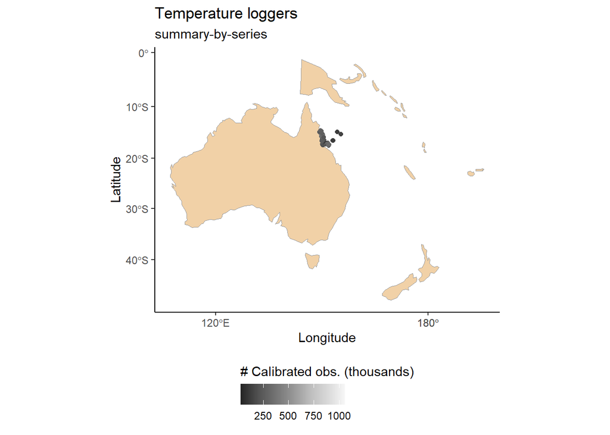

### Map (corrected)

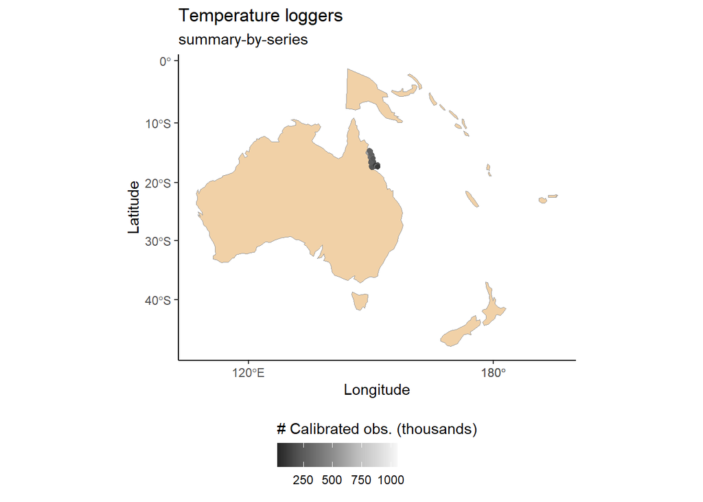

# Data Manipulation

```r
#--- filtering data ---#
CairnsRegion3 <- CairnsRegion2%>%
  filter(between (depth, 7,15))

#--- summarising data ---#
CairnsRegion3 %>% summarise(
  number_of_reefs = length(site),
  min_depth = min(depth),
  max_depth = max(depth),
  mean_depth = mean(depth)
  )
```

```
##   number_of_reefs min_depth max_depth mean_depth
## 1              25         7        10       8.48
```

The default for max. observations downloaded per site is set to 1000. If downloading a large amount of data set the **size** parameter to a large number

Lets start by downloading data from **2015-01-01** to **2020-12-31** for the reefs that we identified as being in Cairns Region earlier.

The list of reefs will be store in variable **reef_list**

```r
#--- Importing data from multiple sites ---#
reef_list <- CairnsRegion3$series_id
aims_data_per_series <- function(series_number, my_api_key, ...) {
  aims_data("temp_loggers", api_key = my_api_key,  summary = "daily",
            filters = list(series_id = series_number, ...))
}

CairnsTemp <- purrr::map_df(reef_list, aims_data_per_series,
                         my_api_key = my_api_key,
                         from_date = "2015-01-01",
                         thru_date = "2020-12-31",
                         size = 3000)
```

Lets look at a quick summary of out data

```r
CairnsTemp_summary <- CairnsTemp %>%
  group_by(site) %>%
  summarise(
    earliest_date = min(time),
    latest_date = max(time),
    days_obsrvd = length(time))
print(as_tibble(CairnsTemp_summary), n=length(CairnsTemp_summary$site))
```

```
## # A tibble: 24 x 4
##    site                    earliest_date       latest_date         days_obsrvd
##    <chr>                   <dttm>              <dttm>                    <int>
##  1 Agincourt Reef Number 1 2015-01-01 00:00:00 2020-02-08 00:00:00        1942
##  2 Arlington Reef          2015-01-01 00:00:00 2020-02-12 00:00:00        1283
##  3 Dip Reef                2015-05-13 00:00:00 2019-06-10 00:00:00        1488
##  4 Farquharson Reef        2015-12-18 00:00:00 2020-02-23 00:00:00        1527
##  5 Feather Reef            2015-01-01 00:00:00 2020-02-22 00:00:00        1872
##  6 Green Island, Qld       2015-03-17 00:00:00 2020-12-31 00:00:00        2114
##  7 Grub Reef               2018-04-23 00:00:00 2020-06-07 00:00:00         777
##  8 Hastings Reef           2015-12-06 00:00:00 2020-12-31 00:00:00        2170
##  9 Havannah Island         2017-04-25 00:00:00 2020-12-31 00:00:00        1346
## 10 Hedley Reef             2015-01-01 00:00:00 2020-02-18 00:00:00        1871
## 11 Helix Reef              2015-01-01 00:00:00 2020-06-06 00:00:00        1980
## 12 John Brewer             2017-05-02 00:00:00 2020-12-31 00:00:00        1338
## 13 Kelso Reef              2015-01-01 00:00:00 2020-05-30 00:00:00         982
## 14 McCulloch Reef          2015-12-14 00:00:00 2020-02-19 00:00:00        1527
## 15 Moore Reef              2015-12-09 00:00:00 2017-12-17 00:00:00         740
## 16 Myrmidon Reef           2015-01-01 00:00:00 2020-12-31 00:00:00        2051
## 17 Opal Reef               2015-05-13 00:00:00 2020-12-31 00:00:00        1172
## 18 Orpheus Island          2016-02-02 00:00:00 2018-01-17 00:00:00         716
## 19 Peart Reef              2015-01-01 00:00:00 2020-02-20 00:00:00        1870
## 20 Rib Reef                2015-01-01 00:00:00 2020-12-31 00:00:00        2178
## 21 Roxburgh Reef           2018-02-26 00:00:00 2020-04-30 00:00:00         795
## 22 St Crispin Reef         2015-01-01 00:00:00 2020-12-31 00:00:00        2171
## 23 Taylor Reef             2015-12-19 00:00:00 2020-02-24 00:00:00        1527
## 24 Thetford Reef           2015-05-14 00:00:00 2020-12-31 00:00:00        3895
```

Great Job! But to make our lives easier before we move on, will we separate the time column into the variables **YEAR**,**MONTH**, and **DAY**.

```r
CairnsTemp2 <- CairnsTemp %>%
  mutate(time = as_date(time)) %>% #reformat date column as a 'date' variable
  separate(time,
           sep="-",
           remove=FALSE,
           into = c("YEAR", "MONTH", "DAY")) %>%
  mutate(YEAR = as.numeric(YEAR),
         MONTH = as.numeric(MONTH),
         DAY = as.numeric(DAY))

# quick check to see if it worked

names(CairnsTemp2)
```

```
##  [1] "deployment_id"       "site"                "site_id"
##  [4] "subsite"             "subsite_id"          "series"
##  [7] "series_id"           "depth"               "lat"
## [10] "lon"                 "serial_num"          "time_coverage_start"
## [13] "time_coverage_end"   "parameter"           "parameter_id"
## [16] "time"                "YEAR"                "MONTH"
## [19] "DAY"                 "uncal_min"           "uncal_max"
## [22] "uncal_val"           "uncal_count"         "cal_min"
## [25] "cal_max"             "cal_val"             "cal_count"
## [28] "qc_min"              "qc_max"              "qc_val"
## [31] "qc_count"
```

Lets save this dataframe. Although it would be easy enough for potential collaborators to run this script image you were working with a large dataframe and/or model that was slow to work with. It will save you time by not having to download all the AIMS temperature logger data everytime you want to work on it as well.

Saving dataframes is easy. We will save the dataframe in a new directory called **‘files’**. To do so, uncomment the first line of code below.

```r
#dir.create("files")
save(CairnsTemp2, file="./files/CairnsTemp2.Rda")
```

# Formating dataframe for FormatTable

Below is how you would upload your saved dataframe

```r
#load dataframe
load("./files/CairnsTemp2.Rda")
```

```r
#--- formatting data for table ---#
#extracting summer months
summer <- CairnsTemp2 %>%
  filter(MONTH == c(1,2,3,12)); unique(summer$MONTH)
```

```
## [1]  1  2  3 12
```

```r
#If you want to save, uncomment lines below
#save(summer, file = "./files/summer.Rda")

#--- gather yearly means ---#
mst <- summer %>%
  group_by(site, YEAR)%>%
  na.omit() %>%
  summarise(temp_mean = mean(cal_val),
             max_mean = mean(cal_max),
             depth_mean = mean(depth),
             range_mean = mean(cal_max - cal_min)) %>%
  ungroup()
head(mst)
```

```
## # A tibble: 6 x 6
##   site                     YEAR temp_mean max_mean depth_mean range_mean
##   <chr>                   <dbl>     <dbl>    <dbl>      <dbl>      <dbl>
## 1 Agincourt Reef Number 1  2015      28.3     28.6       10.2      0.971
## 2 Agincourt Reef Number 1  2016      28.9     29.3       10.2      0.843
## 3 Agincourt Reef Number 1  2017      29.2     29.5       10.0      0.735
## 4 Agincourt Reef Number 1  2018      28.6     28.8        9        0.607
## 5 Agincourt Reef Number 1  2019      28.4     28.6        9        0.548
## 6 Agincourt Reef Number 1  2020      28.9     29.3        9        0.802
```

The function **dcast** does a lot of heavy lifting of us, so we must be kind to it. **dcast** will reformat the data to by listing ‘sites’ within rows and ‘Year’ as the columns. Lets run the code and see what it looks like.

We will collect data for temperature **mean**, **max**, **range**, and logger **depth** separately and then bring all the data back together.

```r
#--- getting data into table format in R ---#
mst_temp <- mst %>%
  dcast(site~YEAR, value.var = "temp_mean")
colnames(mst_temp)[2:length(colnames(mst_temp))] = paste0('Mean_',colnames(mst_temp)[2:length(colnames(mst_temp))])

mst_max <- mst %>%
  dcast(site~YEAR, value.var = "max_mean")
colnames(mst_max)[2:length(colnames(mst_temp))] = paste0('Max_',colnames(mst_max)[2:length(colnames(mst_temp))])

mst_depth <- mst %>%
  dcast(site~YEAR, value.var = "depth_mean")
colnames(mst_depth)[2:length(colnames(mst_temp))] = paste0('Depth_',colnames(mst_depth)[2:length(colnames(mst_temp))])

mst_range <- mst %>%
  dcast(site~YEAR, value.var = "range_mean")
colnames(mst_range)[2:length(colnames(mst_temp))] = paste0('Range_',colnames(mst_range)[2:length(colnames(mst_temp))])

head(mst_temp)
```

```
##                      site Mean_2015 Mean_2016 Mean_2017 Mean_2018 Mean_2019
## 1 Agincourt Reef Number 1  28.27616  28.91765  29.17690  28.55218  28.40078
## 2          Arlington Reef  28.82748  29.39288  28.69800  28.61701  28.47179
## 3                Dip Reef  27.97726  28.84212  28.94193  28.42593  28.15752
## 4        Farquharson Reef  28.34740  28.97551  29.34368  28.38915  28.34595
## 5            Feather Reef  28.80133        NA  28.86209  28.52608  28.43290
## 6       Green Island, Qld        NA        NA        NA        NA  28.39670
##   Mean_2020
## 1  28.94203
## 2  29.41008
## 3        NA
## 4  29.37184
## 5  29.62456
## 6  29.28322
```

```r
# join all the data together
mst_all <- full_join(mst_temp,mst_max, by="site") %>%
  full_join(mst_range, by ="site") %>%
  full_join(mst_depth[c(1,7)], by = "site") %>%
  mutate_if(is.numeric, round, digits = 2); names(mst_all)
```

```
##  [1] "site"       "Mean_2015"  "Mean_2016"  "Mean_2017"  "Mean_2018"
##  [6] "Mean_2019"  "Mean_2020"  "Max_2015"   "Max_2016"   "Max_2017"
## [11] "Max_2018"   "Max_2019"   "Max_2020"   "Range_2015" "Range_2016"
## [16] "Range_2017" "Range_2018" "Range_2019" "Range_2020" "Depth_2020"
```

```r
#save data
#save(mst_all, file="./files/mst_all.Rda")
```

# FormatTable

```r
#--- put table into formattable ---#
# load data
#load("./files/mst_all.RDA")
mst_all2 <- mst_all
mst_all2[is.na(mst_all2)] = ''

CairnsRegion_Table <- formattable(mst_all2,
            align = c("l","r","r","r","r","r","r","r","r","r","r","r","r"
                      ,"r","r","r","r","r","r","r","r","r","r","r","r","r"),
            list(site = formatter(
              "span",
              style = ~style(color = "grey", font.weigh = "bold")),
              area(col = `Mean_2015`:`Mean_2020`) ~ color_tile("white","red"),
              area(col = `Max_2015`:`Max_2020`) ~ color_tile("yellow","red"),
              area(col = `Range_2015`:`Range_2020`) ~ color_tile("palegreen","green3"),
              Depth_2020 = color_bar("pink", 'proportion', 0.2)))

CairnsRegion_Table = as.datatable(formattable(CairnsRegion_Table)) %>%
  formatStyle(colnames(mst_all2), `text-align` = 'right')
```

Save table using the ‘export’ button in RStudio

# Density Plots

## Descriptive statistics

```r
#--- descriptive statistics ---#
CairnsTemp4 <- CairnsTemp2 %>%
  mutate(heatwave_years = case_when(
    YEAR == "2016" ~ "heatwave_yr",
    YEAR == "2017" ~ "heatwave_yr",
    YEAR == "2020" ~ "heatwave_yr",
    TRUE ~ "ambient_yr"))

agg_data <- CairnsTemp4 %>%
  group_by(heatwave_years)%>%
  na.omit() %>%
  summarise(temp_mean = mean(cal_val),
            max_mean = mean(cal_max),
            range_mean = mean(cal_max - cal_min)) %>%
  ungroup()

agg_data[nrow(agg_data)+1,] <- list("Difference",
                                    agg_data$temp_mean[2]-agg_data$temp_mean[1],
                                    agg_data$max_mean[2]- agg_data$max_mean[1],
                                    agg_data$range_mean[2] - agg_data$range_mean[1])
agg_data
```

```
## # A tibble: 3 x 4
##   heatwave_years temp_mean max_mean range_mean
##   <chr>              <dbl>    <dbl>      <dbl>
## 1 ambient_yr        26.2     26.5       0.486
## 2 heatwave_yr       27.0     27.3       0.534
## 3 Difference         0.788    0.797     0.0476
```

```r
# But his doesn't help us with determining summer temperature

#load("./files/summer.Rda")

CairnsTemp5 <- summer %>%
  mutate(heatwave_years = case_when(
    YEAR == "2016" ~ "heatwave_yr",
    YEAR == "2017" ~ "heatwave_yr",
    YEAR == "2020" ~ "heatwave_yr",
    TRUE ~ "ambient_yr"))

agg_data <- CairnsTemp5 %>%
  group_by(heatwave_years)%>%
  na.omit() %>%
  summarise(temp_mean = mean(cal_val),
            max_mean = max(cal_max),
            range_mean = mean(cal_max - cal_min)) %>%
  ungroup()

agg_data[nrow(agg_data)+1,] <- list("Difference",
                                    agg_data$temp_mean[2]-agg_data$temp_mean[1],
                                    agg_data$max_mean[2]- agg_data$max_mean[1],
                                    agg_data$range_mean[2] - agg_data$range_mean[1])
agg_data
```

```
## # A tibble: 3 x 4
##   heatwave_years temp_mean max_mean range_mean
##   <chr>              <dbl>    <dbl>      <dbl>
## 1 ambient_yr        28.4     31.1        0.584
## 2 heatwave_yr       29.0     32.1        0.704
## 3 Difference         0.671    0.990      0.120
```

## Density plot

**Note: Make sure your colors are friendly to the colorblind!**

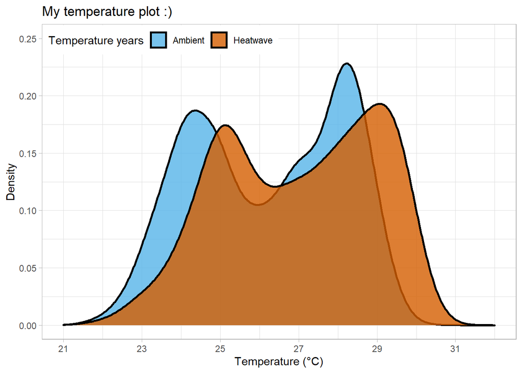

```r
my_temperature_plot <- CairnsTemp4 %>%
  na.omit() %>%
  ggplot(aes(cal_val))+
  geom_density(aes(fill = heatwave_years),
               size = 1,
               position = "identity",
               alpha = 0.8,
               adjust = 1.5) +
  scale_fill_manual(labels = c("Ambient", "Heatwave"),
                    values = c("#56B4E9", "#D55E00")) +
  scale_x_continuous(breaks = seq(21,34,2),
                     limits = c(21,32))+
  theme_light()+
  xlab("Temperature (\u00B0C)") +
  ylab("Density")+
  ylim(0,0.25)+
  ggtitle("My temperature plot :)")+
  labs(fill = "Temperature years") +
  theme(legend.direction = "horizontal",
        legend.position = c(.25,.95)) +
  guides(shape = guide_legend(override.aes = list(size = 0.2))); my_temperature_plot
```

```r
# what are the exact temperature with the max. frequency

ggplot_build(my_temperature_plot)$data[[1]] %>%
  group_by(fill) %>%
  filter(density == max(density)) %>%
  ungroup() %>%
  kable("html") %>%
  kable_styling("striped") %>%
  scroll_box(width = "100%")
```

| fill | y | x | density | scaled | ndensity | count | n | flipped_aes | PANEL | group | ymin | ymax | weight | colour | alpha | size | linetype |
| --- | --- | --- | --- | --- | --- | --- | --- | --- | --- | --- | --- | --- | --- | --- | --- | --- | --- |
| #56B4E9 | 0.2282475 | 28.23288 | 0.2282475 | 1 | 1 | 4100.237 | 17964 | FALSE | 1 | 1 | 0 | 0.2282475 | 1 | black | 0.8 | 1 | 1 |
| #D55E00 | 0.1930424 | 29.07241 | 0.1930424 | 1 | 1 | 2174.044 | 11262 | FALSE | 1 | 2 | 0 | 0.1930424 | 1 | black | 0.8 | 1 | 1 |

Save the plot. There are one or two way of doing this

```r
###saving plot####
ggsave(filename = "./files/my_temperature_plot.pdf",
       width = 8,
       height = 6,
       device = 'pdf',
       dpi = 500)
dev.off()

#OR

pdf(file = "./files/my_temperature_plot2.pdf",
    width = 8,
    height = 6)
my_temperature_plot
dev.off()
```

You can also get the same information from the dataframe

```r
ambient_temp_summer <- CairnsTemp4 %>%
  filter(heatwave_years == "ambient_yr") %>%
  mutate_if(is.numeric, round, digits = 2) %>%
  {.$cal_val} %>%
  table() %>%
  which.max() %>%
  names()
heatwave_temp_summer <- CairnsTemp4 %>%
  filter(heatwave_years == "heatwave_yr") %>%
  mutate_if(is.numeric, round, digits = 2) %>%
  {.$cal_val} %>%
  table() %>%
  which.max() %>%
  names()
```

```
##   ambient_temp_summer heatwave_temp_summer
## 1               28.32                29.32
```

Why are the numbers from the plot and dataframe different?